### Title: Sudoku wielkosc problemu: 15

# Algorytm mrówkowy w rozwiązywaniu sudoku

```r
source("mrowki.sudoku.tests.r")
```

Zastosowanie algorytmu mrówkowego do problemu rozwiązywania sudoku z różnymi parametrami algorytmu (ilość mrówek, początkowa wielkość feromonów, współczynnik degradacji feromonów) oraz różnej instancji problemu

## 2. Wielkosc problemu 15

2.1 Test 1:

- Ilość mrówek = 1,
- współczynnik degradacji 0.9,
- startowe feromony 0.5

```r
mrowki.sudoku.tests.test_main(15, 1, 0.9, 0.5)
```

```
## [1] "Sudoku do rozwiazania:"
##       [,1] [,2] [,3] [,4] [,5] [,6] [,7] [,8] [,9]
##  [1,]    1    4    0    2    3    0    5    6    9
##  [2,]    2    5    8    1    0    9    3    4    7
##  [3,]    3    6    9    4    5    7    1    2    8
##  [4,]    4    7    1    3    0    2    6    9    5
##  [5,]    5    8    2    6    9    1    0    0    3
##  [6,]    6    9    3    5    7    4    2    8    1
##  [7,]    7    1    4    8    2    3    9    5    6
##  [8,]    8    0    5    9    0    0    0    3    4
##  [9,]    0    3    6    7    0    0    8    0    0
## [1] "Rozwiazanie:"
##       [,1] [,2] [,3] [,4] [,5] [,6] [,7] [,8] [,9]
##  [1,]    1    4    7    2    3    8    5    6    9
##  [2,]    2    5    8    1    6    9    3    4    7
```

[output cut: 215 more lines]

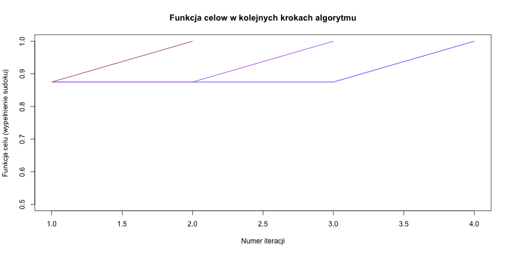

2.2 Test 2:

- Ilość mrówek = 2,
- współczynnik degradacji 0.9,
- startowe feromony 0.5

```r
mrowki.sudoku.tests.test_main(15, 2, 0.9, 0.5)
```

```
## [1] "Sudoku do rozwiazania:"
##       [,1] [,2] [,3] [,4] [,5] [,6] [,7] [,8] [,9]
##  [1,]    1    4    7    2    0    8    0    6    0
##  [2,]    2    5    8    1    6    9    3    4    7
##  [3,]    3    0    9    4    5    7    1    2    8
##  [4,]    0    7    1    3    8    2    6    9    5
##  [5,]    5    8    2    6    9    1    4    0    0
##  [6,]    6    9    3    5    7    0    2    0    1
##  [7,]    7    1    4    8    2    0    9    5    6
##  [8,]    8    0    5    9    1    6    7    0    4
##  [9,]    9    3    6    0    4    5    0    0    2
## [1] "Rozwiazanie:"
##       [,1] [,2] [,3] [,4] [,5] [,6] [,7] [,8] [,9]
##  [1,]    1    4    7    2    3    8    5    6    9
##  [2,]    2    5    8    1    6    9    3    4    7
```

[output cut: 215 more lines]

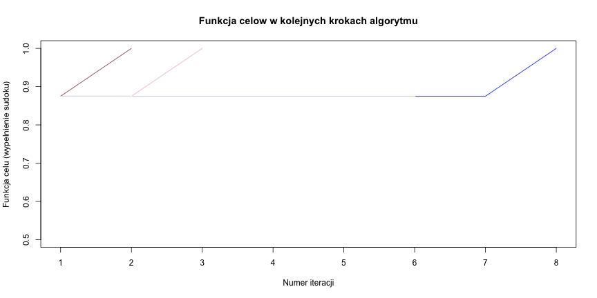

2.3 Test 3:

- Ilość mrówek = 4,
- współczynnik degradacji 0.9,
- startowe feromony 0.5

```r
mrowki.sudoku.tests.test_main(15, 4, 0.9, 0.5)
```

```
## [1] "Sudoku do rozwiazania:"
##       [,1] [,2] [,3] [,4] [,5] [,6] [,7] [,8] [,9]
##  [1,]    1    0    7    2    3    8    0    6    9
##  [2,]    2    5    8    1    6    9    3    4    7
##  [3,]    3    6    0    4    5    0    1    2    8
##  [4,]    4    7    1    3    8    2    0    9    0
##  [5,]    5    0    2    6    9    1    0    0    3
##  [6,]    6    9    3    5    0    4    2    8    1
##  [7,]    7    1    4    0    0    3    9    5    6
##  [8,]    0    2    0    9    1    6    7    3    4
##  [9,]    9    3    6    7    4    5    0    1    2
## [1] "Rozwiazanie:"
##       [,1] [,2] [,3] [,4] [,5] [,6] [,7] [,8] [,9]
##  [1,]    1    4    7    2    3    8    5    6    9
##  [2,]    2    5    8    1    6    9    3    4    7
```

[output cut: 215 more lines]

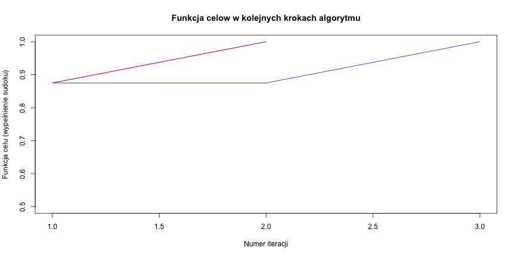

2.4 Test 4:

- Ilość mrówek = 10,
- współczynnik degradacji 0.9,
- startowe feromony 0.5

```r
mrowki.sudoku.tests.test_main(15, 10, 0.9, 0.5)
```

```
## [1] "Sudoku do rozwiazania:"
##       [,1] [,2] [,3] [,4] [,5] [,6] [,7] [,8] [,9]
##  [1,]    1    4    0    0    3    0    5    6    9
##  [2,]    2    5    8    1    6    9    3    4    0
##  [3,]    3    6    9    4    0    7    1    2    8
##  [4,]    4    7    0    3    8    2    6    9    5
##  [5,]    5    0    2    6    9    1    4    7    3
##  [6,]    6    9    3    0    7    4    0    8    0
##  [7,]    7    0    0    8    2    3    9    5    6
##  [8,]    8    2    5    9    1    6    0    3    4
##  [9,]    9    3    6    0    4    5    8    1    0
## [1] "Rozwiazanie:"
##       [,1] [,2] [,3] [,4] [,5] [,6] [,7] [,8] [,9]
##  [1,]    1    4    7    2    3    8    5    6    9
##  [2,]    2    5    8    1    6    9    3    4    7
```

[output cut: 215 more lines]

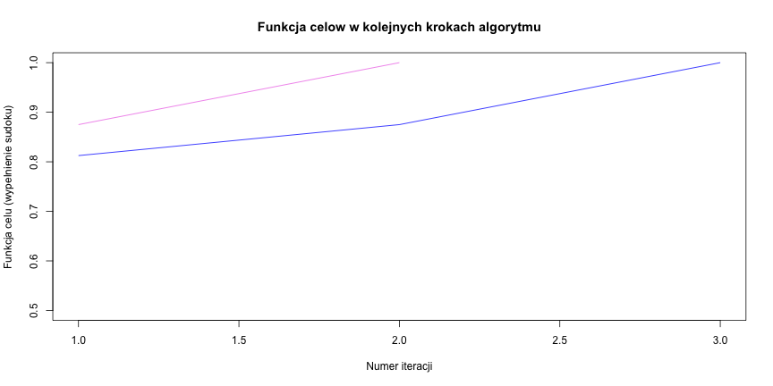

2.5 Test 5:

- Ilość mrówek = 2,
- współczynnik degradacji 0.9,
- startowe feromony 0.5

```r
mrowki.sudoku.tests.test_main(15, 2, 0.9, 0.5)
```

```
## [1] "Sudoku do rozwiazania:"
##       [,1] [,2] [,3] [,4] [,5] [,6] [,7] [,8] [,9]
##  [1,]    1    4    7    2    3    8    5    6    9
##  [2,]    0    5    0    1    6    9    3    4    7
##  [3,]    3    6    9    0    0    0    1    2    8
##  [4,]    0    7    0    3    8    2    6    9    5
##  [5,]    5    8    2    6    9    1    0    0    0
##  [6,]    6    9    3    5    7    4    2    8    1
##  [7,]    7    1    0    8    2    0    9    5    0
##  [8,]    8    0    5    9    1    6    7    3    4
##  [9,]    9    3    6    0    4    5    8    1    2
## [1] "Rozwiazanie:"
##       [,1] [,2] [,3] [,4] [,5] [,6] [,7] [,8] [,9]
##  [1,]    1    4    7    2    3    8    5    6    9
##  [2,]    2    5    8    1    6    9    3    4    7
```

[output cut: 215 more lines]

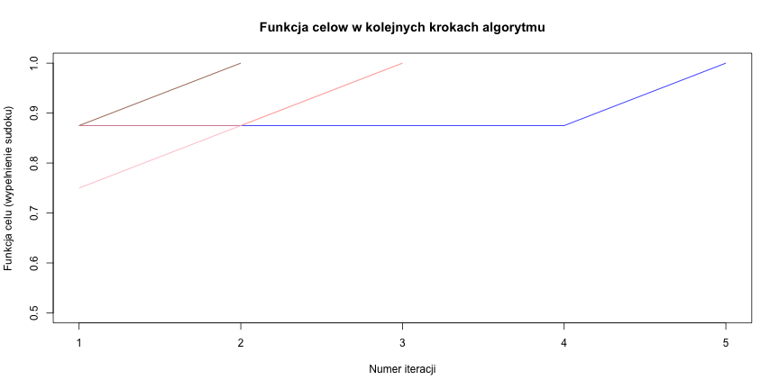

2.6 Test 6:

- Ilość mrówek = 2,
- współczynnik degradacji 0.75,
- startowe feromony 0.5

```r
mrowki.sudoku.tests.test_main(15, 2, 0.75, 0.5)
```

```
## [1] "Sudoku do rozwiazania:"
##       [,1] [,2] [,3] [,4] [,5] [,6] [,7] [,8] [,9]
##  [1,]    1    0    7    0    3    8    5    6    9
##  [2,]    2    0    8    0    6    9    3    4    7
##  [3,]    0    6    9    4    5    7    1    2    8
##  [4,]    4    0    1    3    8    2    0    9    5
##  [5,]    5    8    2    6    9    1    4    7    3
##  [6,]    6    9    0    5    7    0    2    8    0
##  [7,]    0    1    4    8    2    3    9    5    6
##  [8,]    8    2    5    9    1    6    7    3    0
##  [9,]    9    3    6    0    4    0    8    1    0
## [1] "Rozwiazanie:"
##       [,1] [,2] [,3] [,4] [,5] [,6] [,7] [,8] [,9]
##  [1,]    1    4    7    2    3    8    5    6    9
##  [2,]    2    5    8    1    6    9    3    4    7
```

[output cut: 215 more lines]

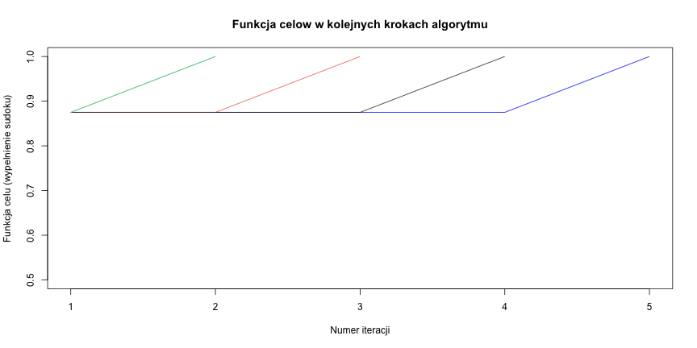

2.7 Test 7:

- Ilość mrówek = 2,
- współczynnik degradacji 0.5,
- startowe feromony 0.5

```r
mrowki.sudoku.tests.test_main(15, 2, 0.5, 0.5)
```

```
## [1] "Sudoku do rozwiazania:"
##       [,1] [,2] [,3] [,4] [,5] [,6] [,7] [,8] [,9]
##  [1,]    1    4    7    2    3    8    5    6    9
##  [2,]    2    5    0    1    6    9    3    0    7
##  [3,]    3    6    0    4    5    7    0    2    8
##  [4,]    4    7    1    3    8    2    6    0    5
##  [5,]    5    8    0    6    9    1    4    7    0
##  [6,]    6    9    3    5    7    4    2    8    1
##  [7,]    7    1    4    8    2    3    9    0    0
##  [8,]    8    2    0    9    0    6    7    3    4
##  [9,]    9    3    0    0    0    5    8    1    0
## [1] "Rozwiazanie:"
##       [,1] [,2] [,3] [,4] [,5] [,6] [,7] [,8] [,9]
##  [1,]    1    4    7    2    3    8    5    6    9
##  [2,]    2    5    8    1    6    9    3    4    7
```

[output cut: 215 more lines]

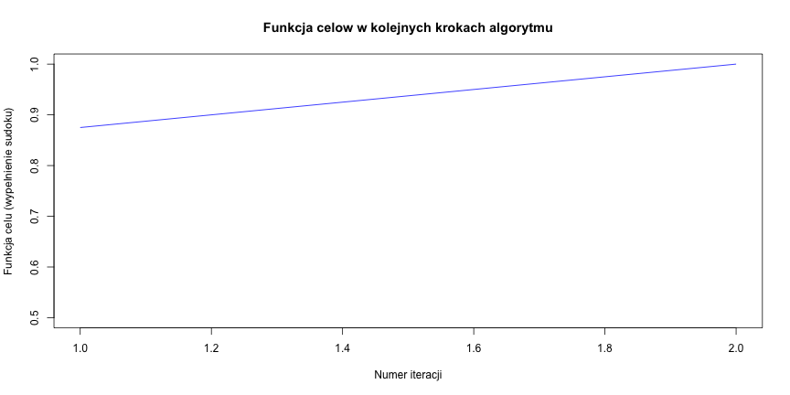

2.8 Test 8:

- Ilość mrówek = 2,
- współczynnik degradacji 0.15,
- startowe feromony 0.5

```r
mrowki.sudoku.tests.test_main(15, 2, 0.15, 0.5)
```

```
## [1] "Sudoku do rozwiazania:"
##       [,1] [,2] [,3] [,4] [,5] [,6] [,7] [,8] [,9]
##  [1,]    1    0    7    2    3    8    5    6    0
##  [2,]    2    5    8    1    6    9    3    0    7
##  [3,]    3    6    0    4    0    7    1    2    8
##  [4,]    4    0    1    3    0    2    6    9    5
##  [5,]    5    8    2    0    9    0    4    0    3
##  [6,]    6    9    0    5    7    4    2    8    1
##  [7,]    7    0    4    8    2    3    9    5    6
##  [8,]    0    2    5    9    1    6    7    0    4
##  [9,]    9    3    6    7    4    5    0    1    2
## [1] "Rozwiazanie:"
##       [,1] [,2] [,3] [,4] [,5] [,6] [,7] [,8] [,9]
##  [1,]    1    4    7    2    3    8    5    6    9
##  [2,]    2    5    8    1    6    9    3    4    7
```

[output cut: 215 more lines]

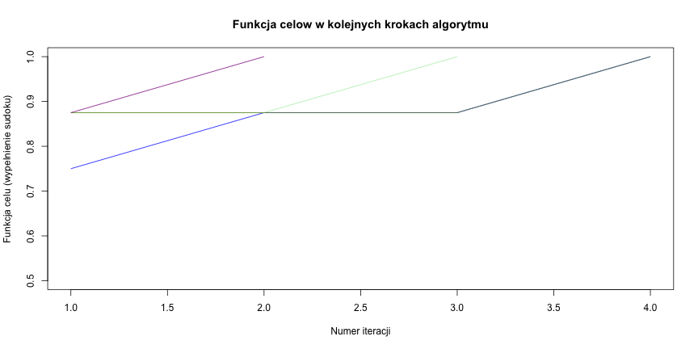

2.9 Test 9:

```r
mrowki.sudoku.tests.test_main(15, 1, 0.5, 0.9)
```

```
## [1] "Sudoku do rozwiazania:"
##       [,1] [,2] [,3] [,4] [,5] [,6] [,7] [,8] [,9]
##  [1,]    1    4    7    0    3    8    5    6    9
##  [2,]    2    5    8    0    6    9    3    0    7
##  [3,]    3    6    0    4    5    7    1    2    8
##  [4,]    4    7    0    3    8    2    0    9    5
##  [5,]    5    8    2    6    9    1    0    0    3
##  [6,]    0    9    3    5    7    4    0    8    1
##  [7,]    7    1    4    0    2    3    9    5    6
##  [8,]    8    2    5    0    1    6    7    3    0
##  [9,]    9    3    6    0    4    5    8    1    0
## [1] "Rozwiazanie:"
##       [,1] [,2] [,3] [,4] [,5] [,6] [,7] [,8] [,9]
##  [1,]    1    4    7    2    3    8    5    6    9
##  [2,]    2    5    8    1    6    9    3    4    7
```

[output cut: 215 more lines]

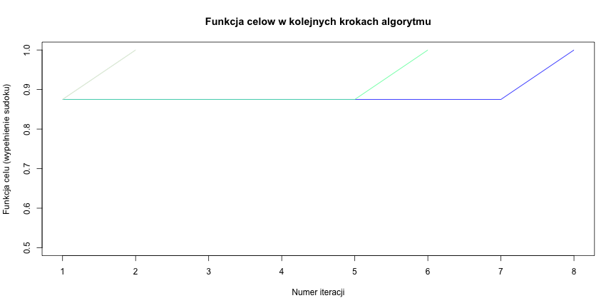

2.10 Test 10:

- Ilość mrówek = 2,
- współczynnik degradacji 0.5,
- startowe feromony 0.75

```r
mrowki.sudoku.tests.test_main(15, 2, 0.5, 0.75)
```

```
## [1] "Sudoku do rozwiazania:"
##       [,1] [,2] [,3] [,4] [,5] [,6] [,7] [,8] [,9]
##  [1,]    0    4    7    2    3    8    5    6    0
##  [2,]    0    5    8    0    6    9    3    4    7
##  [3,]    3    6    0    0    5    0    1    2    8
##  [4,]    4    7    1    3    8    2    6    9    5
##  [5,]    5    8    2    6    9    0    4    7    3
##  [6,]    6    9    0    0    7    4    2    0    0
##  [7,]    7    1    4    0    2    3    9    5    6
##  [8,]    8    0    0    9    1    6    7    3    4
##  [9,]    9    3    6    7    4    5    8    1    2
## [1] "Rozwiazanie:"
##       [,1] [,2] [,3] [,4] [,5] [,6] [,7] [,8] [,9]
##  [1,]    1    4    7    2    3    8    5    6    9
##  [2,]    2    5    8    1    6    9    3    4    7
```

[output cut: 215 more lines]

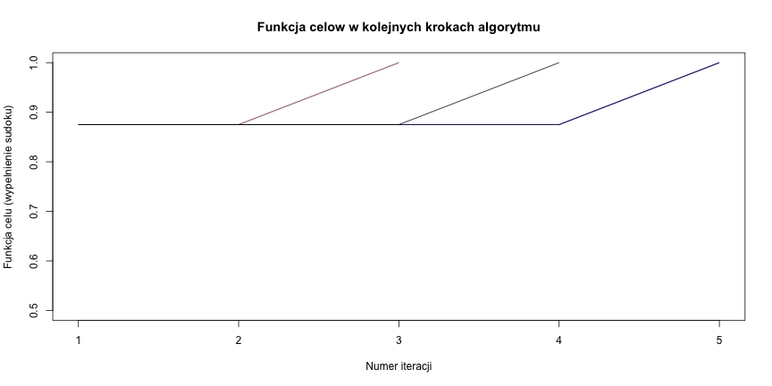

2.11 Test 11:

- Ilość mrówek = 2,
- współczynnik degradacji 0.5,
- startowe feromony 0.5

```r
mrowki.sudoku.tests.test_main(15, 2, 0.5, 0.5)
```

```
## [1] "Sudoku do rozwiazania:"
##       [,1] [,2] [,3] [,4] [,5] [,6] [,7] [,8] [,9]
##  [1,]    1    0    7    0    0    8    5    6    0
##  [2,]    2    5    8    1    6    0    3    4    7
##  [3,]    3    0    9    4    5    7    1    2    8
##  [4,]    4    7    1    0    0    2    6    9    0
##  [5,]    5    8    2    0    9    1    0    0    3
##  [6,]    6    9    3    0    7    4    2    8    1
##  [7,]    7    1    4    8    2    3    9    5    6
##  [8,]    8    2    5    9    1    6    0    3    4
##  [9,]    9    3    6    7    4    5    8    1    0
## [1] "Rozwiazanie:"
##       [,1] [,2] [,3] [,4] [,5] [,6] [,7] [,8] [,9]
##  [1,]    1    4    7    2    3    8    5    6    9
##  [2,]    2    5    8    1    6    9    3    4    7
```

[output cut: 215 more lines]

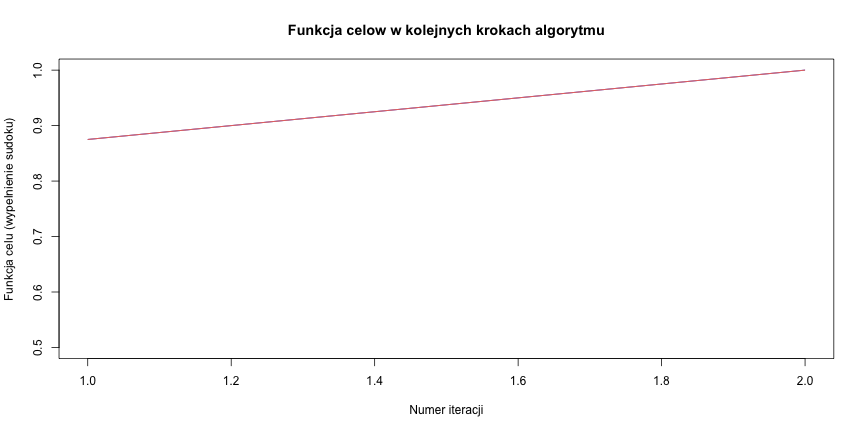

2.12 Test 12:

- Ilość mrówek = 2,
- współczynnik degradacji 0.5,
- startowe feromony 0.15

```r
mrowki.sudoku.tests.test_main(15, 2, 0.5, 0.15)
```

```
## [1] "Sudoku do rozwiazania:"
##       [,1] [,2] [,3] [,4] [,5] [,6] [,7] [,8] [,9]
##  [1,]    1    4    7    2    3    0    5    0    9
##  [2,]    0    5    8    1    6    9    3    4    7
##  [3,]    3    6    9    4    5    7    1    2    8
##  [4,]    4    7    1    3    8    2    6    0    0
##  [5,]    5    8    2    6    9    1    4    7    3
##  [6,]    6    9    0    0    7    0    2    8    1
##  [7,]    7    1    4    8    2    3    0    0    6
##  [8,]    8    0    5    0    1    0    7    3    4
##  [9,]    9    3    6    7    4    5    0    1    0
## [1] "Rozwiazanie:"
##       [,1] [,2] [,3] [,4] [,5] [,6] [,7] [,8] [,9]
##  [1,]    1    4    7    2    3    8    5    6    9
##  [2,]    2    5    8    1    6    9    3    4    7
```

[output cut: 215 more lines]

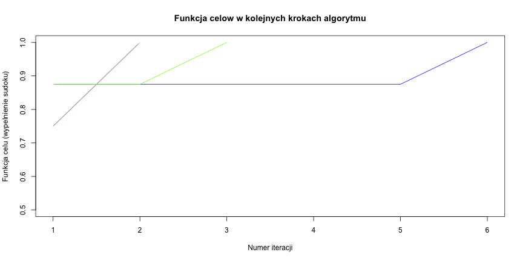